# STAT 480 Final Project

Raghav Goyal (raghavg4@illinois.edu)

Brian Lim (brianl8@illinois.edu)

Daniel Alonso Gonzalez (da39@illinois.edu)

2024-12-15

# Introduction

## Project Definition

In today’s urban landscapes, shared mobility solutions like bikeshare programs play a critical role in enhancing transportation efficiency, reducing environmental impact, and fostering healthier lifestyles. The *Chicago Divvy Bikeshare Program*, operated under Lyft and owned by the Chicago Department of Transportation, is a cornerstone of of the city’s urban mobility infrastructure, offering an extensive network of stations and bikes to support diverse commuter needs. By analyzing data from this program, we aim to uncover actionable insights that can optimize bikeshare operations and enhance user experiences.

## Project Objectives

This project leverages Divvy data spanning a full 12 months (November 2023 to October 2024), which provides comprehensive information on bike rides, station details, and user demographics. The primary objectives are: - *Optimizing Station Placements and Bike Availability* - *Member Retention and Engagement*

# Data Preprocessing, Feature Engineering, and Initial Analysis

```r
nov23 = read.csv("Data/202311-divvy-tripdata.csv")
dec23 = read.csv("Data/202312-divvy-tripdata.csv")
jan24 = read.csv("Data/202401-divvy-tripdata.csv")
feb24 = read.csv("Data/202402-divvy-tripdata.csv")
mar24 = read.csv("Data/202403-divvy-tripdata.csv")
apr24 = read.csv("Data/202404-divvy-tripdata.csv")
may24 = read.csv("Data/202405-divvy-tripdata.csv")
jun24 = read.csv("Data/202406-divvy-tripdata.csv")
jul24 = read.csv("Data/202407-divvy-tripdata.csv")
aug24 = read.csv("Data/202408-divvy-tripdata.csv")
sep24 = read.csv("Data/202409-divvy-tripdata.csv")
oct24 = read.csv("Data/202410-divvy-tripdata.csv")
df = rbind(nov23, dec23, jan24, feb24, mar24, apr24, may24, jun24, jul24,aug24,
           sep24, oct24)
```

We have loaded 12 month historic data ranging from November 2023 to October 2024. Each of these CSV files had over 100,000 observations and had sizes ranging from 25MB to 160MB. After combining, let’s get an idea of the overall dataset.

```r
format(object.size(df), units = "auto")
```

```
## [1] "1.9 Gb"
```

Looks like we are working with just under 2GB worth of data, which is definitely a large dataset in terms of both memory/storage, as well as its potential computational expenses.

The overall dataset has almost 6 million rows across 13 distinct columns. On first glance, we can see that a decent chunk of start and end station names and ids are empty and a few values for ending longitude and ending latitude are missing. To get up and running, we can do some quick cleaning to make the data a bit more manageable. This includes dropping the initial ride id column as it contains no discernible information, changing certain categorical columns into factors, and changing our start and end trip times to a proper datetime format to extract as much information.

```r
# Dropping ID column since no discernible information
df$ride_id = NULL

# Change ride type to factor
df$rideable_type = as.factor(df$rideable_type)

# Change start and end from character to datetime format
df$started_at = ymd_hms(df$started_at)
df$ended_at = ymd_hms(df$ended_at)

# fetching data with missing end trip coordinates
missing_coords = df %>%
  filter(is.na(end_lat) | is.na(end_lng))

# Checking where missing data is from
missing_coords$month = month(missing_coords$started_at, label = TRUE)
missing_coords$year = year(missing_coords$started_at)
table(missing_coords$month, missing_coords$year)
```

```
##
##       2023 2024
##   Jan    0  288
##   Feb    0  318
##   Mar    0  396
##   Apr    0  479
##   May    0  824
##   Jun    0 1141
##   Jul    0 1137
##   Aug    0  978
##   Sep    0  703
##   Oct    0  564
##   Nov  350    0
##   Dec  239    0
```

It seems the 7417 missing values in the ending coordinates are pretty spread out across each month, since this is a fairly negligible amount compared to the near 6 million observations, we can simply drop them. Especially, considering that these coordinates are important pieces of information with no real potential way of imputing.

```r
df <- df %>%
  drop_na(end_lat, end_lng)
```

Let’s take a closer look at the empty rows in the start and end station columns. These empty occurrences are spread across the time frame, so it is not the case that 1 or a few months are missing this data.

```r
# Filling with NAs
df$start_station_name[df$start_station_name == ""] = NA
df$start_station_id[df$start_station_id == ""] = NA
df$end_station_name[df$end_station_name == ""] = NA
df$end_station_id[df$start_station_id == ""] = NA

na_stations <- df %>%
  filter(is.na(start_station_name) |
         is.na(start_station_id) |
         is.na(end_station_name) |
         is.na(end_station_id))
```

```r
table(na_stations$rideable_type, na_stations$member_casual)
```

```
##
##                    casual member
##   classic_bike        240    150
##   electric_bike    571220 984626
##   electric_scooter  59475  37035
```

We can see that most empty station data are for electric bikes and scooters and this makes sense as only classic bikes need to be operated at Divvy specific docking stations and e-bikes and scooters are eligible to be parked at any public racks for free and other legal public locations for a small cost. Since the values for the classic bike are actually “missing” we will drop these. Also, there are no instances where station id contains information and station name does not or vice-versa and there is no discernible information for station id so we will drop the two corresponding columns for this.

```r
df <- df %>%
  filter(!(is.na(start_station_name) & rideable_type == "classic_bike"),
         !(is.na(end_station_name) & rideable_type == "classic_bike"))

df <- df %>%
  select(-start_station_id, -end_station_id)
```

For the rest of the station NAs, we can fill them up by using a two-element tuple containing the longitude and latitude of of their start and end trip. Dropping these values would not be advisable as they constitute the majority of total observations containing e-bike and scooter specific data.

```r
df$start_station_name = ifelse(
  is.na(df$start_station_name),
  paste0("(", df$start_lat, ", ", df$start_lng, ")"),
  df$start_station_name
)

df$end_station_name = ifelse(
  is.na(df$end_station_name),
  paste0("(", df$end_lat, ", ", df$end_lng, ")"),
  df$end_station_name
)

df$start_station_name = as.factor(df$start_station_name)
df$end_station_name = as.factor(df$end_station_name)
```

The data we currently have has the trip start and end time down to the second. By finding the differences between these two columns, we can create a new feature to represent the trip duration in minutes. To ensure data quality we will also filter out “negative” trip durations or overly long times like over 500 minutes long.

```r
df$trip_duration = as.numeric(difftime(df$ended_at, df$started_at, units = "mins"))
df <- df %>%
  filter(trip_duration >= 0 & trip_duration <= 500)
```

Let’s also create a few additional time-based features. These include, extracting the specific months, day, and hours of the rides. We can also create a entirely new feature called part of the day, where we segment mornings, afternoons, evenings, and nights. Below is a quick preview of these new features.

```r
df$month = month(df$started_at, label = TRUE, abbr = TRUE)
df$day <- wday(df$started_at, label = TRUE, abbr = TRUE)
df$hour <- hour(df$started_at)

df$part_of_day <- case_when(
  df$hour >= 5 & df$hour < 12 ~ "Morning",     # 5 AM to 12 PM
  df$hour >= 12 & df$hour < 17 ~ "Afternoon", # 12 PM to 5 PM
  df$hour >= 17 & df$hour < 21 ~ "Evening",   # 5 PM to 9 PM
  TRUE ~ "Night"                              # 9 PM to 5 AM
)
df$part_of_day <- as.factor(df$part_of_day)

head(df[, c("started_at", "month", "day", "hour", "part_of_day")])
```

|  | started_at | month | day | hour | part_of_day |
| --- | --- | --- | --- | --- | --- |
| 1 | 2023-11-30 21:50:05 | Nov | Thu | 21 | Night |
| 2 | 2023-11-03 09:44:02 | Nov | Fri | 9 | Morning |
| 3 | 2023-11-30 11:39:44 | Nov | Thu | 11 | Morning |
| 4 | 2023-11-08 10:01:45 | Nov | Wed | 10 | Morning |
| 5 | 2023-11-03 16:20:25 | Nov | Fri | 16 | Afternoon |
| 6 | 2023-11-30 16:15:53 | Nov | Thu | 16 | Afternoon |

# Further Exploratory Analysis and Visualization

We have completed a fair amount of data cleaning and feature engineering to this point. Let’s now get into the crux of the data and explore further and generate some useful visualizations and potentiall actionable insights.

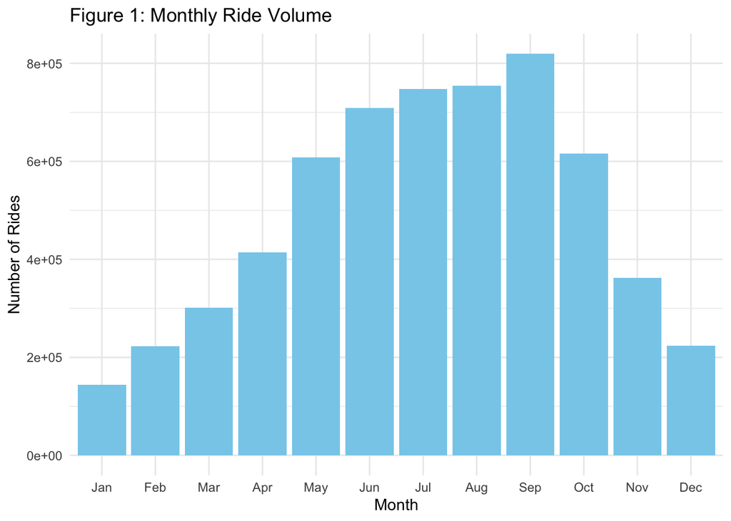

```r
# Ride volume by month
ggplot(df, aes(x = month)) +
  geom_bar(fill = "skyblue") +
  labs(title = "Figure 1: Monthly Ride Volume", x = "Month", y = "Number of Rides") +
  theme_minimal()
```

In the entire 12-month period we have 5.9 million trips, and we can see that most of these trips occur in the summer months, with some decent amount in the fall and spring as well. It is clear to see that winter trips are not as popular which makes sense due to the harsh conditions we see in Chicago during that time.

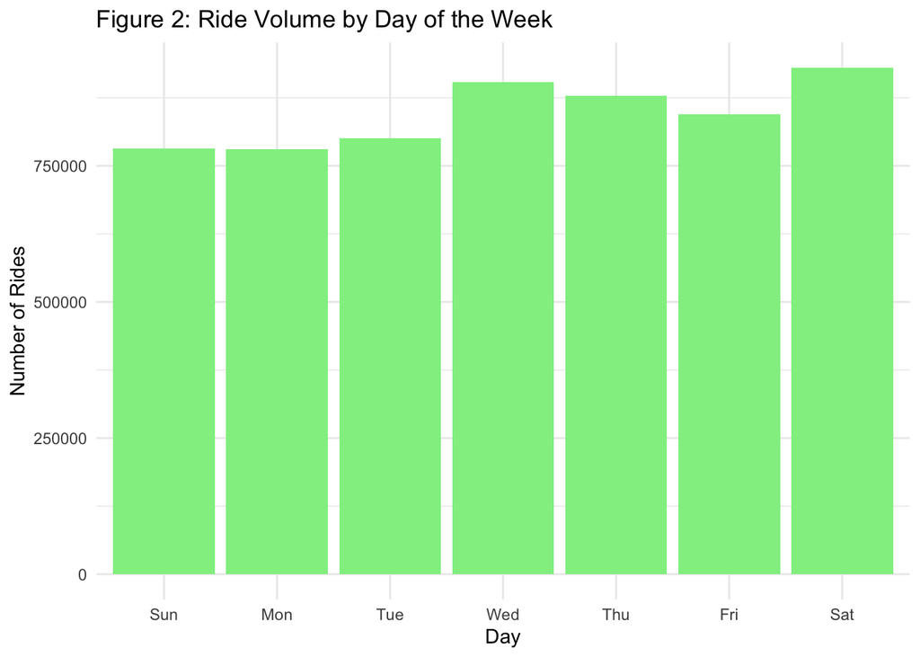

```r
# Ride volume by day of the week
ggplot(df, aes(x = day)) +
  geom_bar(fill = "lightgreen") +
  labs(title = "Figure 2: Ride Volume by Day of the Week", x = "Day", y = "Number of Rides") +
  theme_minimal()
```

Rides are extremely consistent throughout the week. It may be the case that during the weekdays they are used for peak commute (school, work, etc), while on the weekends they can be used for leisure.

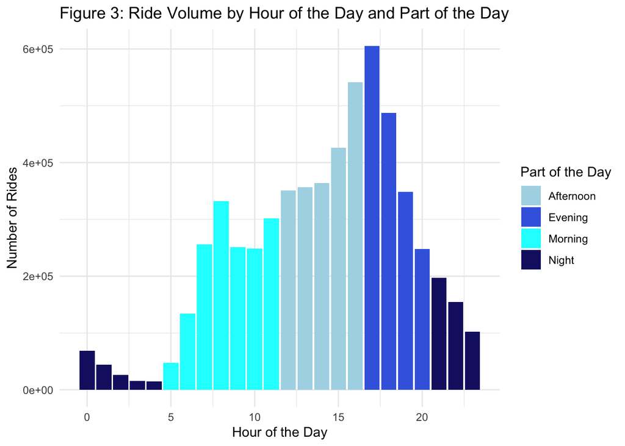

```r
#Ride volume by hour of the day and part of the day
ggplot(df, aes(x = hour, fill = part_of_day)) +
  geom_bar() +
  labs(
    title = "Figure 3: Ride Volume by Hour of the Day and Part of the Day",
    x = "Hour of the Day",
    y = "Number of Rides",
    fill = "Part of the Day"
  ) +
  scale_fill_manual(
    values = c("Morning" = "cyan", "Afternoon" = "lightblue",
               "Evening" = "royalblue", "Night" = "midnightblue")
  ) +
  theme_minimal()
```

Most rides occur during the late afternoon and early evening portions of the day, from around 3PM to 6PM. This makes sense as this time is also associated with peak commute and is typically considered “pleasant” on off-days around the city. There is still a decent amount of rides throughout the day, although this undertandibly drops significantly during the dead of night.

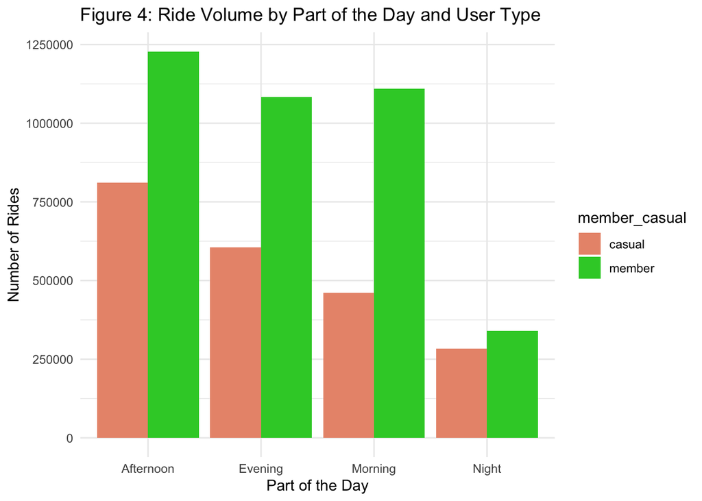

```r
# Ride patterns by part of the day and user type
ggplot(df, aes(x = part_of_day, fill = member_casual)) +
  geom_bar(position = "dodge") +
  labs(title = "Figure 4: Ride Volume by Part of the Day and User Type", x = "Part of the Day", y = "Number of Rides") +
  scale_fill_manual(values = c("casual" = "darksalmon", "member" = "limegreen")) +
  theme_minimal()
```

For overall trips, we have around 63% of them being from members and the remaining 37% of them being casual or single-use riders. Pretty much across the board time-wise, we see a consistent trend of member riders being more frequent than casual, however, this difference is less for night rides. Let’s check how long these rides typically are.

```r
num_long_trips = df %>%
  filter(trip_duration > 60) %>%
  nrow()
print(num_long_trips)
```

```
## [1] 143097
```

There are 143 thousand trips that are longer than 1 hour. This means that the vast majority of trips are within the 1-hour time frame, so let’s check the distribution of trip length from 0-60 minutes.

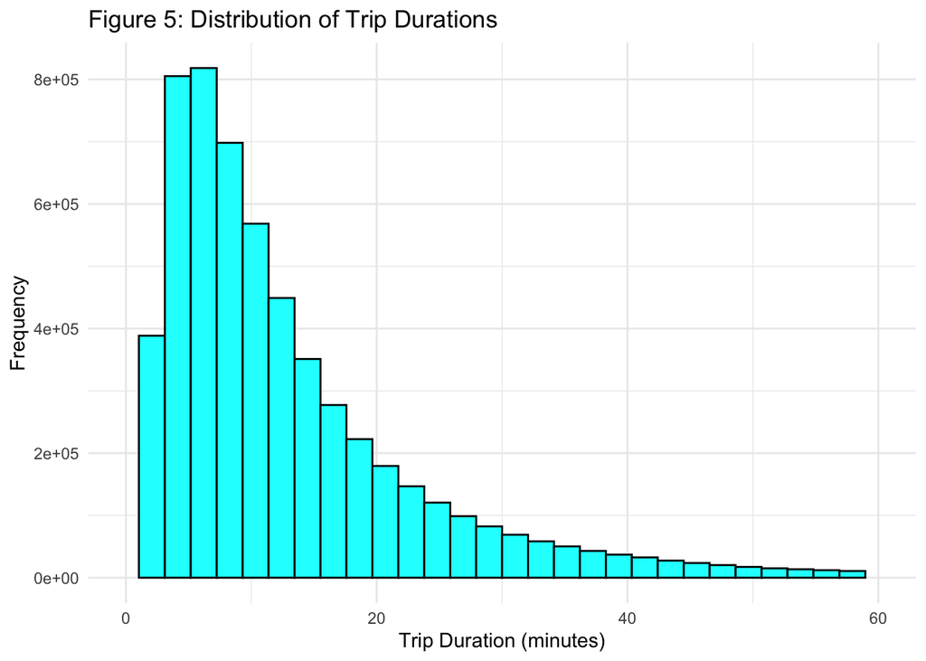

```r
# Distribution of trip duration
ggplot(df, aes(x = trip_duration)) +
  geom_histogram(bins = 30, fill = "cyan", color = "black") +
  xlim(0, 60) + # Focus on trips within 1 hour
  labs(title = "Figure 5: Distribution of Trip Durations", x = "Trip Duration (minutes)", y = "Frequency") +
  theme_minimal()
```

In general, most trips are fairly short and run from 2-15 minutes. This is expected as people likely use these vehicles for short, convenient commutes across the city.

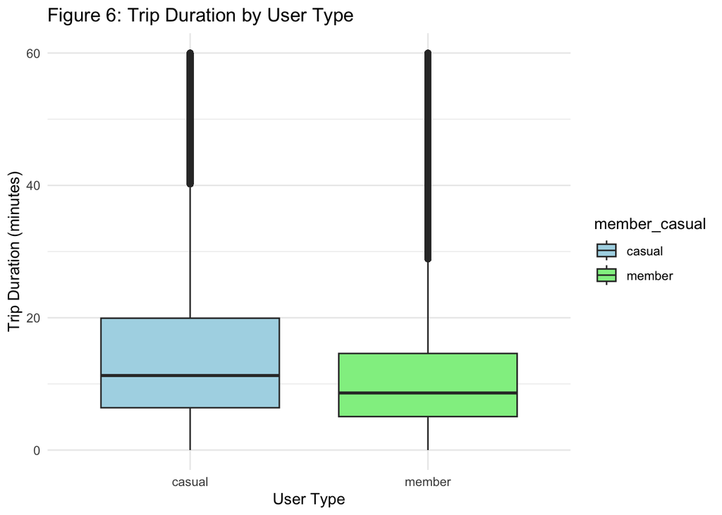

```r
# Trip duration by user type
ggplot(df, aes(x = member_casual, y = trip_duration, fill = member_casual)) +
  geom_boxplot() +
  ylim(0, 60) + # Focus on trips within 1 hour
  labs(title = "Figure 6: Trip Duration by User Type", x = "User Type", y = "Trip Duration (minutes)") +
  scale_fill_manual(values = c("casual" = "lightblue", "member" = "lightgreen")) +
  theme_minimal()
```

Casual riders are more likely to have longer trips. This may be the case due to pricing. Members do not have to pay an unlocking fee and variable rates are lower, so members are not subject to greater costs upfront to deter them from shorter rides. Single-use riders however, may feel the need to get the most out of their unlocking fee and opt for longer rides.

Classic bikes and electric bikes take up more than 95% of total ride volume, but let’s see if there are any differences in trip duration for each ride type.

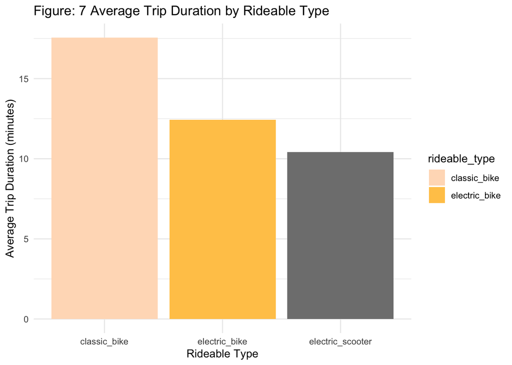

```r
df %>%
  group_by(rideable_type) %>%
  summarize(avg_trip_duration = mean(trip_duration, na.rm = TRUE)) %>%
  ggplot(aes(x = rideable_type, y = avg_trip_duration, fill = rideable_type)) +
  geom_bar(stat = "identity") +
  labs(
    title = "Figure: 7 Average Trip Duration by Rideable Type",
    x = "Rideable Type",
    y = "Average Trip Duration (minutes)"
  ) +
  scale_fill_manual(values = c("classic_bike" = "#FFDDC1", "electric_bike" = "#FFC857", "scooter" = "#6A4C93")) +
  theme_minimal()
```

It seems trips with classic bikes have longer trip times compared to the e-vehicles. This could be so due to the e-vehicles having higher operational speeds, leading to a smaller duration. Let’s now check out what some of the most popular starting and ending docking stations are.

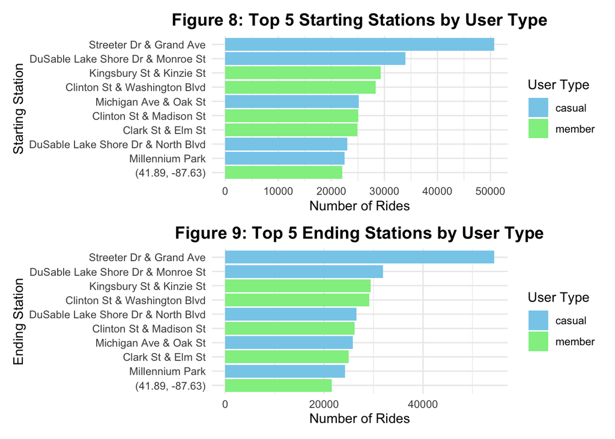

```r
# Aggregate and find top 5 starting stations for each user type
top_starting_stations <- df %>%
  group_by(start_station_name, member_casual) %>%
  summarize(num_rides = n(), .groups = "drop") %>%
  arrange(member_casual, desc(num_rides)) %>%
  group_by(member_casual) %>%
  slice_max(num_rides, n = 5)  # Get top 5 for each group


# Aggregate and find top 5 ending stations for each user type
top_ending_stations <- df %>%
  group_by(end_station_name, member_casual) %>%
  summarize(num_rides = n(), .groups = "drop") %>%
  arrange(member_casual, desc(num_rides)) %>%
  group_by(member_casual) %>%
  slice_max(num_rides, n = 5)  # Get top 5 for each group

# Generate the two plots (reuse your code for the plots)
# Top 5 Starting Stations
plot_starting <- ggplot(top_starting_stations, aes(x = reorder(start_station_name, num_rides), y = num_rides, fill = member_casual)) +
  geom_bar(stat = "identity", position = "dodge") +
  coord_flip() +
  labs(
    title = "Figure 8: Top 5 Starting Stations by User Type",
    x = "Starting Station",
    y = "Number of Rides",
    fill = "User Type"
  ) +
  scale_fill_manual(values = c("casual" = "skyblue", "member" = "lightgreen")) +
  theme_minimal() +
  theme(plot.title = element_text(hjust = 0.5, size = 14, face = "bold"))

# Top 5 Ending Stations
plot_ending <- ggplot(top_ending_stations, aes(x = reorder(end_station_name, num_rides), y = num_rides, fill = member_casual)) +
  geom_bar(stat = "identity", position = "dodge") +
  coord_flip() +
  labs(
    title = "Figure 9: Top 5 Ending Stations by User Type",
    x = "Ending Station",
    y = "Number of Rides",
    fill = "User Type"
  ) +
  scale_fill_manual(values = c("casual" = "skyblue", "member" = "lightgreen")) +
  theme_minimal() +
  theme(plot.title = element_text(hjust = 0.5, size = 14, face = "bold"))

# Combine plots in a 2x1 layout
combined_plot <- plot_starting / plot_ending  # Use '/' to stack vertically

# Display the combined plot
combined_plot
```

From figures 8 and 9 above, we can see that a lot of the starting and ending stations are same for both casual riders and members. Most of these are official docking stations like “Streeter Dr & Grand Ave”, however there is one very popular general location of (41.89, -87.63) which happens to be in the River North Area where the Courthouse Place is. This is nationally recognised as a historical landmark which may point to its popularity.